# Final Exam

# Problem 2: Unbalanced Data (15 pts)

A researcher is trying to build a predictive model for distinguishing between real and AI generated images. She collected a random sample ($n=10,000$) of tweets/posts that included images. Expert analysts were hired to label the images as real or AI generated. They determined that 1000 were AI generated and 9000 were real.

She tasked her grad student with building a logistic regression model to predict the probability that a new image is AI generated. After reading on the internet, the grad student became concerned that the data was *unbalanced* and fit the model using a weighted log-loss
$$-\sum_{i=1}^n w_i \left[ y_i \log \hat{p}(x_i) + (1-y_i) \log
(1-\hat{p}(x_i)) \right]$$
where $y_i = 1$ if AI generated ($y_i=0$ if real) and $w_i = 1$ if $y_i = 1$ (AI) and $w_i = 1/9$ if $y_i = 0$ (real). This makes $\sum_i w_iy_i = \sum_i w_i(1-y_i) = 1000$. That is the total weight of the AI images equals the total weight of the real images. Note: An similar alternative is to downsample the real images; that is, build a model with 1000 AI and a random sample of 1000 real images. The grad student fits the model using the weights and is able to make predictions $\hat{p}(x)$.

While the grad student is busy implementing this model, the researcher grabbed another 1000 random tweets/posts with images and had the experts again label them real or AI. Excitedly, the grad student makes predictions on the test data. However, the model doesn’t seem to be working well on these new test images. While the AUC appears good, the log-loss and brier scores are really bad.

Hint: By using the weights (or undersampling), the grad student is modifying the base rate (prior class probability).

## a. What is going on? (5 pts)

How can the AUC be strong while the log-loss and brier scores aren’t.

## Modifications done to base rate

- at the beginning the grad student was provided with a dataset that has 10% AI generated images and 90% human generate images.
- However, the weighting that was added later made the dataset into a 50-50 AI generated images and human generate images
- The grad student used this weighted dataset to train the logit regression which is unable to distinguish the weighted data from the population data.

## Implementations on the new test set

- since the model is trained on the dataset that doesn’t represent the actual population; what it represents is the population that has 50% AI generateed images and 50% human generated image. When the grad student used this particular inaccurate model on the test data set the probability is very off.

## Why AUC strong while the log-loss and brier scores aren’t

- The AUC is a performance metric that measure the ability of a model to rank predictions properly which is different from the actual predicted probability (aka log-loos and brier scores). The undersampling or weighted model only affects the predicted probability but it doesn’t actually affect the ranked order of predictions

## b. What is the remedy? (5 pts)

Specifically, how should the grad student adjust the predictions for the new test images? Use equations and show your work. Hints: the model is outputting $\hat{p}(x) = \widehat{\Pr}(Y=1|X=x)$; consider the log odds and Bayes theorem.

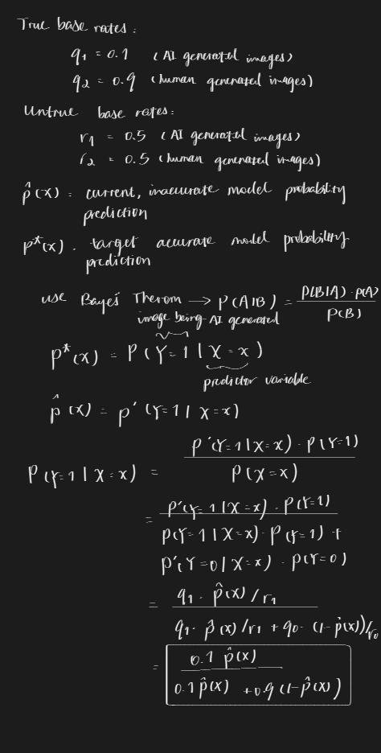

## c. Base rate correction (5 pts)

If the grad student’s weighted model predicts an image is AI generated with $\hat{p}(x) = .80$, what is the updated prediction under the assumption that the true proportion of AI is 1/10.

We can apply the formula we derived from part b to answer this question

$$p^*(x) = \frac{0.1\times0.8}{0.1\times0.8+0.9\times0.2}\approx0.308$$

# Problem 3: Multiclass Classification (10 pts)

You have built a predictive model that outputs a probability vector $\hat{p}(x) = [\hat{p}_1(x), \hat{p}_2(x), \hat{p}_3(x)]$ for a 3-class categorical output. Consider the following loss matrix which includes an option to return *No Decision* if there is too much uncertainty in the label:

|  | $\hat{G} =1$ | $\hat{G} =2$ | $\hat{G} =3$ | No Decision |
| --- | --- | --- | --- | --- |
| $G = 1$ | 0 | 2 | 2 | 1 |
| $G = 2$ | 1 | 0 | 2 | 1 |
| $G = 3$ | 1 | 1 | 0 | 1 |

What label would you output if the estimated probability is: $\hat{p}(x) = [0.25, 0.15, 0.60]$. Show your work.

We are given the estimated probability vector:
$$\hat{p}(x) = [0.25, 0.15, 0.60],$$

We know that expected loss = the sum of (probability X loss) for each class or
$$\text{Expected Loss}(\hat{G}) = \sum_{G=1}^3 \hat{p}_G(x) \cdot
\text{Loss}(G| \hat{G}),$$

For $\hat{G} = 1$:
$$E[L|\hat{G}=1] = 0(0.25) + 1(0.15) + 1(0.60) =
0.75$$
For $\hat{G} = 2$:
$$E[L|\hat{G}=2] = 2(0.25) + 0(0.15) +
1(0.60) = 1.10$$
For $\hat{G} = 3$:
$$E[L|\hat{G}=3] = 2(0.25) +
2(0.15) + 0(0.60) = 0.80$$
For No Decision:
$$E[L|\text{No Decision}] = 1(0.25) + 1(0.15) +
1(0.60) = 1.00$$
Comparing all the expected losses we find that $\hat{G} = 1$ because it has the lowest expected loss of $0.75$

# Problem 4: Donor Acceptance Modeling (40 pts)

The data for this problem is for your private use on this exam only. You may not share or use for any other purposes.

This challenge has you predicting the probability that a pediatric donor heart offer will be Accepted or Rejected. Use the `donor_accept_train.csv` data (available in Canvas) to build a model to predict the probability of `outcome = "Accept"`. The test data `donor_accept_test.csv` is used for making predictions.

A description of the transplant system and variables is provided in `donor_accept_vars.html`.

Hints:

- There are four parts to this problem. Before you being think about how your approach will address all four (for example, your choice of model(s) in part a may influence your approach to part c).
- As always, *before you start coding* write out each step of the process. Think about inputs and outputs.

## a. Probability Prediction Contest (10 pts)

Build a model to predict the probability that an offer will be accepted. Performance is evaluated using log-loss.

*Contest Submission:*

- Submit your predictions on the `donor_accept_test.csv` data. Create a .csv file (ensure comma separated format) named `lastname_firstname.csv` that includes the column named “prob_accept” that is your estimated posterior probability. We will use automated evaluation, so the format must be exact.

*Notes:*

- I suggest you quickly make an initial model without doing any feature engineering or much tuning. There are a lot of features, an endless number of feature engineering tasks, many predictive models each with many tuning parameters to choose from. But just get something that correctly outputs probabilities and use it to complete the other parts to this problem. You can always come back and improve the model if your time permits.
- You must show your code. Because your code may take some time to run, you may want to run the model outside this notebook. If you do so, copy the final code into this notebook and set `eval=FALSE` in the corresponding code chunk(s) so we can see the code, but it won’t run when the notebook compiles.

*Competition Grading:*

- 2 of the 10 points are based on readable code
- 3 of the 10 points are based on a valid submission (e.g., correct number of rows and log-loss beats an intercept only model)
- The remaining 5 points are based on your predictive performance. The top score will receive all 5, the second best 4.93, third best 4.85, etc.

### a.1 Loading and Inspecting Data

```r
library(tidyverse)
library(caret)
library(xgboost)
library(recipes)
library(gridExtra)
# Loading Data
train_data <- read.csv("donor_accept_train-1.csv")
test_data <- read.csv("donor_accept_test.csv")

# Inspecting Data
head(train_data, n = 10)
```

```
##    OFFER_ID outcome OFFER_DATE DISTANCE NUM_REJECT_DON OFFER_TOD    AGE_DON
## 1         1  Reject 2017-09-24  1366.96             66        17  2.2166351
## 2         2  Reject 2017-06-01   920.86             57        21 13.0592507
## 3         3  Reject 2014-11-24   305.69              0        20 15.9007512
## 4         4  Reject 2015-03-23   251.67             18         3  0.3258342
## 5         5  Reject 2019-12-16   956.80              1        17 12.0677222
## 6         6  Reject 2015-04-08   726.00             24         4  3.1848612
## 7         7  Reject 2019-03-25   281.42              1        13 17.0496515
## 8         8  Accept 2017-01-04   287.36              0        15 14.0317456
## 9         9  Reject 2018-06-24   260.57              2        11  2.3835756
## 10       10  Reject 2013-06-25   275.93              0        10 17.5738016
##    GENDER_DON RACE_DON WEIGHT_DON_KG HEIGHT_DON_CM  BMI_DON ABO_DON CPR_ADMIN
## 1           M    Black          16.0         91.00 19.32134       O       Yes
## 2           M Hispanic          43.6        152.00 18.87119       O       Yes
## 3           F    White          75.0        160.00 29.29687       O        No
```

[output cut: 216 more lines]

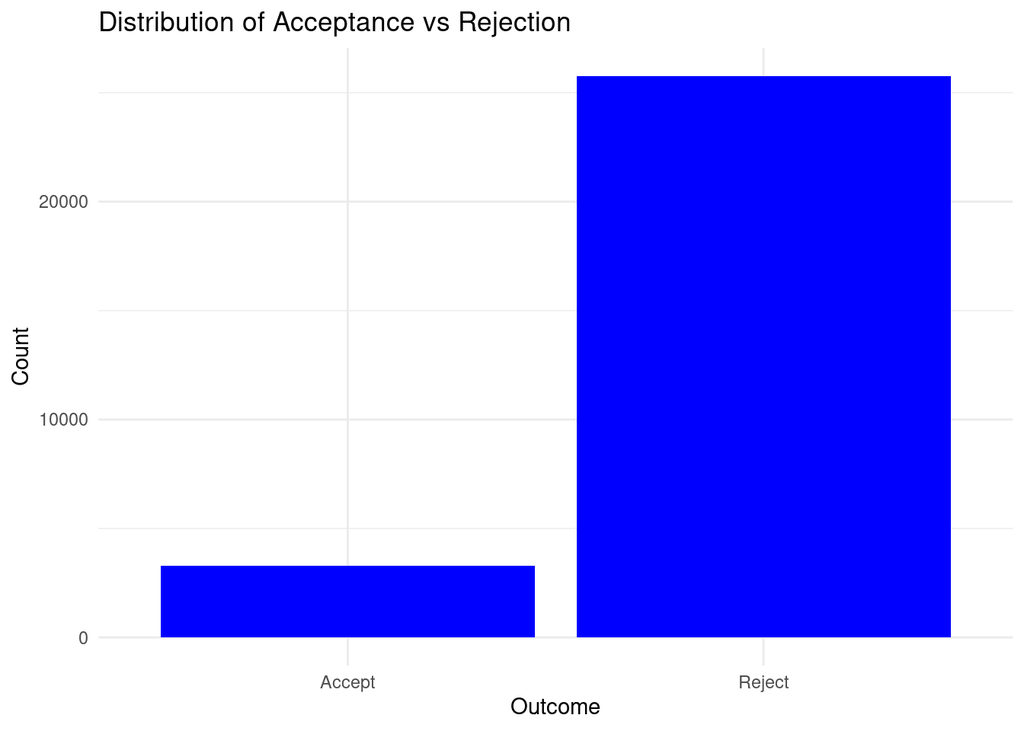

```r
# Plot the class distribution
ggplot(train_data, aes(x = outcome)) +
  geom_bar(fill = "blue") +
  theme_minimal() +
  labs(title = "Distribution of Acceptance vs Rejection",
       x = "Outcome",
       y = "Count")
```

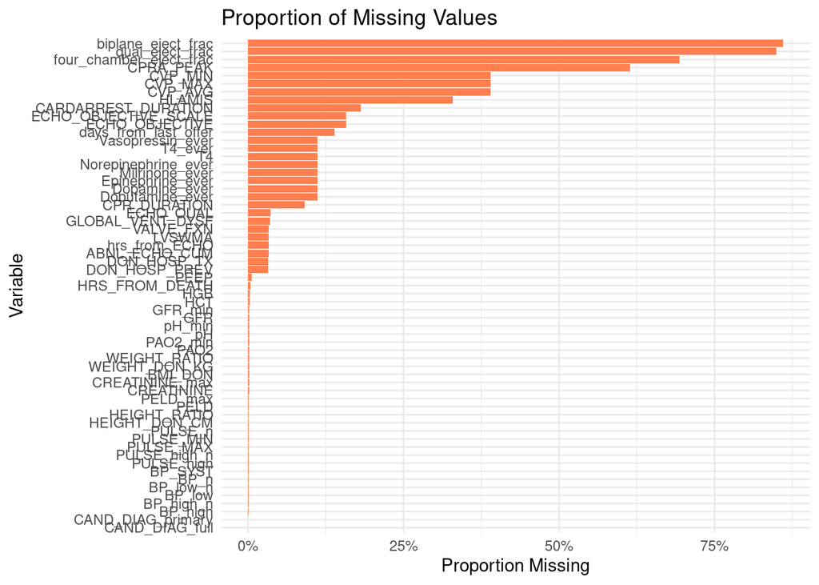

```r
# Check for NA values
na_counts <- colSums(is.na(train_data))
na_props <- data.frame(
  variable = names(na_counts),
  proportion = na_counts / nrow(train_data)
) %>%
  filter(proportion > 0) %>%  # Only keep variables with missing values
  arrange(desc(proportion))

ggplot(na_props, aes(x = reorder(variable, proportion), y = proportion)) +
  geom_bar(stat = "identity", fill = "coral") +
  coord_flip() +
  theme_minimal() +
  labs(title = "Proportion of Missing Values",
       x = "Variable",
       y = "Proportion Missing") +
  scale_y_continuous(labels = scales::percent_format())
```

### a.2 Data Processing/Feature Engineering

```r
# Transforming outcomes to 0 and 1 for computing
train_data$outcome <- ifelse(train_data$outcome == "Accept", 1, 0)

# Define pre-processing recipe
data_recipe <- recipe(outcome ~ ., data = train_data) %>%
  step_rm(OFFER_ID) %>%  # Remove non-predictive identifier
  step_impute_median(all_numeric_predictors()) %>%  # Impute missing values in numeric columns
  step_impute_mode(all_nominal_predictors()) %>%  # Impute missing values in categorical columns
  step_dummy(all_nominal_predictors()) %>%  # Convert categorical columns to dummy variables
  step_center(all_numeric_predictors()) %>%  # Center numeric columns
  step_scale(all_numeric_predictors())       # Scale numeric columns
```

### a.3 Prepping Data and Feature Importance

```r
# Prep and bake data
prep_data <- prep(data_recipe, training = train_data)
train_processed <- bake(prep_data, new_data = NULL)
test_processed <- bake(prep_data, new_data = test_data)
# Initial feature importance calculation
initial_train_matrix <- as.matrix(train_processed %>% select(-outcome))
initial_train_labels <- train_processed$outcome
initial_dtrain <- xgb.DMatrix(data = initial_train_matrix, label = initial_train_labels)

# Train initial model for feature importance
initial_model <- xgb.train(
  params = list(
    objective = "binary:logistic",
    eval_metric = "logloss"
  ),
  data = initial_dtrain,
  nrounds = 500
)

# Get feature importance
importance <- xgb.importance(model = initial_model)
importance_df <- as.data.frame(importance)

# Select top features (adjust threshold as needed)
feature_threshold <- 0.01  # Keep features with gain > 1%
selected_features <- importance_df$Feature[importance_df$Gain > feature_threshold]

# Filter data to include only selected features
train_matrix <- as.matrix(train_processed %>%
                           select(all_of(c(selected_features, "outcome"))) %>%
                           select(-outcome))
train_labels <- train_processed$outcome

test_matrix <- as.matrix(test_processed %>%
                          select(all_of(selected_features)))

# Create final training matrix
dtrain <- xgb.DMatrix(data = train_matrix, label = train_labels)
```

### a.4 Model Training and Evaluation

```r
set.seed(42)
# Define XGBoost parameters
xgb_params <- list(
  objective = "binary:logistic",
  eval_metric = "logloss",
  max_depth = 6,
  eta = 0.1,
  subsample = 0.8,
  colsample_bytree = 0.8
)

# Cross-validation with selected features
cv_model <- xgb.cv(
  params = xgb_params,
  data = dtrain,
  nrounds = 1000, # change this to reduce computing time
  nfold = 5,
  early_stopping_rounds = 20,
  verbose = 0
)

best_nrounds <- cv_model$best_iteration
cat("Best number of rounds:", best_nrounds, "\n")
```

```
## Best number of rounds: 139
```

```r
# Train final model with selected features
xgb_model <- xgb.train(
  params = xgb_params,
  data = dtrain,
  nrounds = best_nrounds,
  verbose = 0
)
```

### a.5 Model Prediction

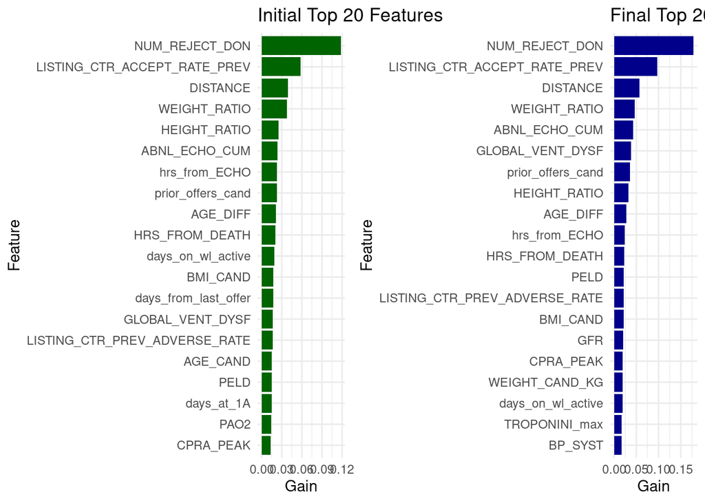

```r
# Predict on test data
dtest <- xgb.DMatrix(data = test_matrix)
predictions <- predict(xgb_model, dtest)

# Create submission file
submission <- data.frame(
  OFFER_ID = test_data$OFFER_ID,
  prob_accept = predictions
)

write.csv(submission, "yang_zhe_with_feature_selection.csv", row.names = FALSE)

# Visualize final feature importance
final_importance <- xgb.importance(model = xgb_model)
final_importance_df <- as.data.frame(final_importance)

# Create comparison plots
p1 <- ggplot(head(importance_df, 20), aes(x = reorder(Feature, Gain), y = Gain)) +
  geom_bar(stat = "identity", fill = "darkgreen") +
  coord_flip() +
  theme_minimal() +
  labs(title = "Initial Top 20 Features",
       x = "Feature",
       y = "Gain")

p2 <- ggplot(head(final_importance_df, 20), aes(x = reorder(Feature, Gain), y = Gain)) +
  geom_bar(stat = "identity", fill = "darkblue") +
  coord_flip() +
  theme_minimal() +
  labs(title = "Final Top 20 Features (After Selection)",
       x = "Feature",
       y = "Gain")

grid.arrange(p1, p2, ncol = 2)
```

```r
# Print feature selection summary
cat("\nFeature Selection Summary:\n")
```

```
##
## Feature Selection Summary:
```

```r
cat("Original number of features:", ncol(initial_train_matrix), "\n")
```

```
## Original number of features: 3225
```

```r
cat("Selected number of features:", length(selected_features), "\n")
```

```
## Selected number of features: 35
```

```r
cat("Percentage of features kept:", round(length(selected_features)/ncol(initial_train_matrix)*100, 2), "%\n")
```

```
## Percentage of features kept: 1.09 %
```

## b: Hard Classification (10 pts)

Suppose you are asked to make a hard classification using the probabilities from part a. Making a false negative is 4 times worse that making a false positive (i.e., $C_{FN} = 4*C_{FP}$).

- What threshold should be used with your predictions? How did you choose?

> 0.2 is the threashold should be used with for prediction

We use the formula: threshold = 1/(1 + CFN/CFP) When CFN = 4*CFP, the optimal threshold is: P(Y=1|X) > 1/(1 + CFN/CFP) = 1/(1 + 4) = 0.2

```r
optimal_threshold <- 0.2
```

- How many of the offers in the test set are classified as *Accept* using this threshold?

> 216 offers are classified as accept using this threashold

```r
predictions <- submission

# Make classifications using the optimal threshold
classifications <- ifelse(predictions$prob_accept >= optimal_threshold, "Accept", "Reject")

# Count number of predicted accepts
num_accepts <- sum(classifications == "Accept")

# Create summary statistics
cat("Optimal threshold:", optimal_threshold, "\n")
```

```
## Optimal threshold: 0.2
```

```r
cat("Number of predicted accepts:", num_accepts, "\n")
```

```
## Number of predicted accepts: 216
```

```r
cat("Percentage of predicted accepts:", round(num_accepts/length(classifications)*100, 2), "%\n")
```

```
## Percentage of predicted accepts: 19.58 %
```

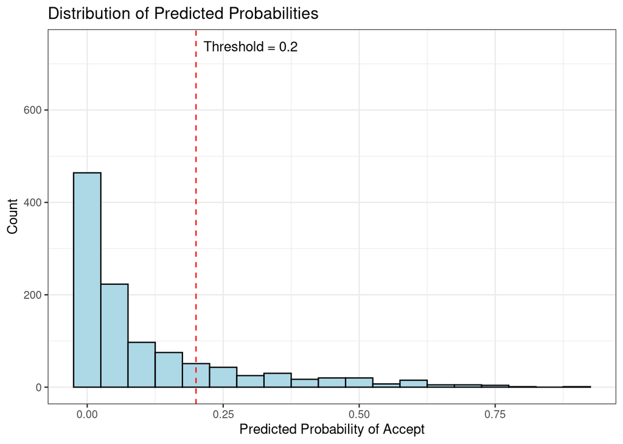

```r
# Visualize prediction distribution with threshold
ggplot(predictions, aes(x = prob_accept)) +
  geom_histogram(binwidth = 0.05, fill = "lightblue", color = "black") +
  geom_vline(xintercept = optimal_threshold, color = "red", linetype = "dashed") +
  annotate("text", x = optimal_threshold + 0.1, y = max(hist(predictions$prob_accept, plot = FALSE)$counts),
           label = paste("Threshold =", optimal_threshold)) +
  labs(title = "Distribution of Predicted Probabilities",
       x = "Predicted Probability of Accept",
       y = "Count")
```

## c. Feature Importance (10 pts)

What features are most important? Describe your results and approach in a language that a clinician would want to listen to and can understand. Be clear about the type of feature importance you used, the data (training, testing) that was used to calculate the feature importance scores, and the limitations inherent in your approach to feature importance.

Notes:

- Your audience is a non-data scientist, so be sure to give a brief high level description of any terms they may not be familiar with.
- You wouldn’t want to show the clinician the feature importance of all 100+ features. Indicate how to selected the *most* important features to report.
- You are not expected to know the clinical meaning of the features.

> Based on our analysis of donor acceptance patterns from the data provided. We are ablet to identify a few key factors that strongly impact the surgery outcome. We used a specific technique called “Gain-based Feature Importance”. Our model went over one hundred plus features but we have identified the top ten most influential factors in donor acceptance which could be found below. However, these factors shuold be considered correlation instead of direct causes for donor heart transpalnt acceptance as more medical research shuold be invested into find the causal relationships.

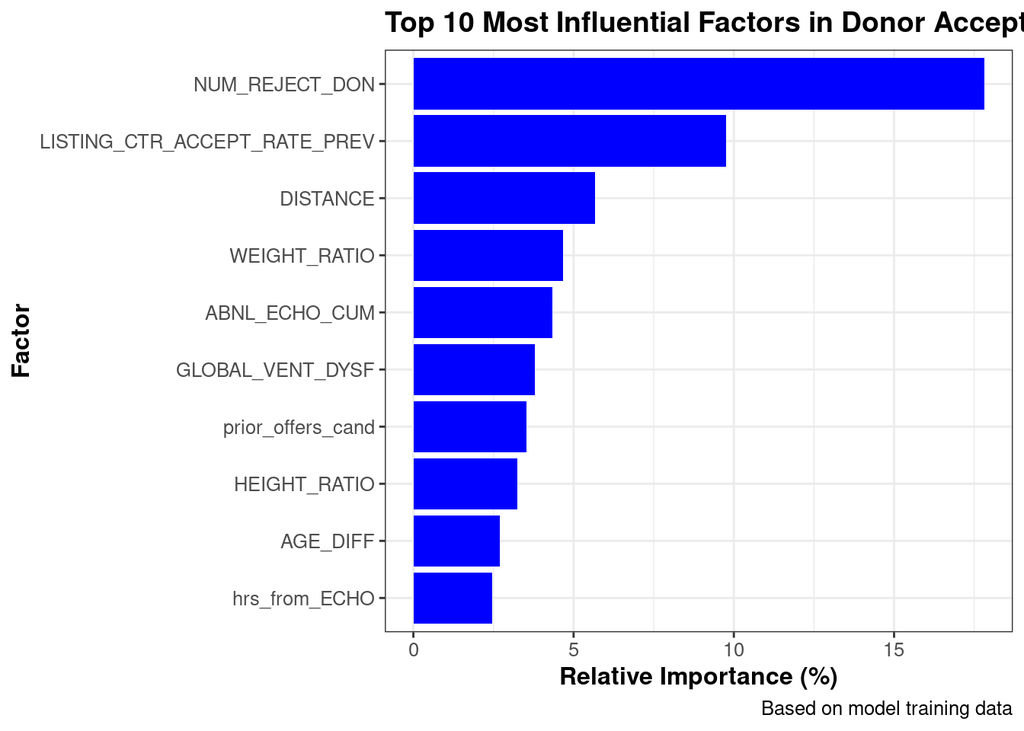

```r
# Get final feature importance from the model
final_importance <- xgb.importance(model = xgb_model)
final_importance_df <- as.data.frame(final_importance)

# Create a cleaner visualization for clinical audience
ggplot(head(final_importance_df, 10), aes(x = reorder(Feature, Gain), y = Gain * 100)) +
  geom_bar(stat = "identity", fill = "blue") +
  coord_flip() +
  theme(
    text = element_text(size = 12),
    axis.title = element_text(face = "bold"),
    plot.title = element_text(size = 14, face = "bold")
  ) +
  labs(
    title = "Top 10 Most Influential Factors in Donor Acceptance",
    x = "Factor",
    y = "Relative Importance (%)",
    caption = "Based on model training data"
  )
```

## d. Calibration (10 pts)

Assess the calibration of your predictions. There are no points off for having a poorly calibrated model; the purpose of this problem is to demonstrate your knowledge of how to evaluate calibration.

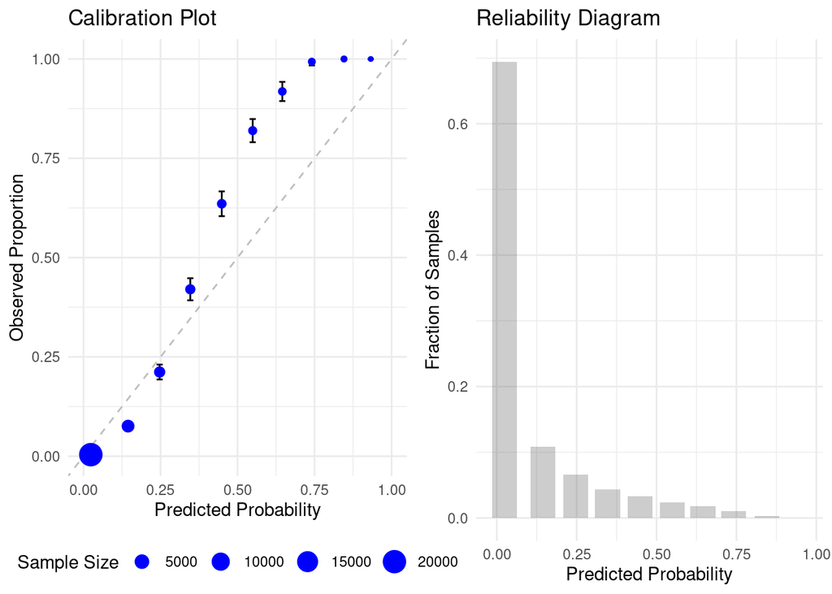

```r
# Get predictions from training data
train_predictions <- predict(xgb_model, dtrain)

# Create data frame with predictions and actual values
calibration_df <- data.frame(
  pred_prob = train_predictions,
  actual = train_labels
)

# Create bins of predicted probabilities (10 bins)
calibration_df$bin <- cut(calibration_df$pred_prob,
                         breaks = seq(0, 1, length.out = 11))

# Calculate calibration metrics for each bin
calibration_summary <- calibration_df %>%
  group_by(bin) %>%
  summarise(
    n = n(),
    mean_pred = mean(pred_prob),
    mean_actual = mean(actual),
    se = sqrt((mean_actual * (1 - mean_actual)) / n)
  )

# Create calibration plot
cal_plot <- ggplot(calibration_summary, aes(x = mean_pred, y = mean_actual)) +
  geom_abline(intercept = 0, slope = 1, linetype = "dashed", color = "gray") +
  geom_errorbar(aes(ymin = mean_actual - 2*se, ymax = mean_actual + 2*se), width = 0.02) +
  geom_point(aes(size = n), color = "blue") +
  scale_x_continuous(limits = c(0, 1)) +
  scale_y_continuous(limits = c(0, 1)) +
  theme_minimal() +
  labs(
    title = "Calibration Plot",
    x = "Predicted Probability",
    y = "Observed Proportion",
    size = "Sample Size"
  ) +
  theme(legend.position = "bottom")

# Create reliability diagram
rel_plot <- ggplot(calibration_summary, aes(x = mean_pred)) +
  geom_bar(aes(y = n/sum(n)), stat = "identity", alpha = 0.3) +
  labs(
    title = "Reliability Diagram",
    x = "Predicted Probability",
    y = "Fraction of Samples"
  ) +
  theme_minimal()

# Display plots side by side
grid.arrange(cal_plot, rel_plot, ncol = 2)
```

```r
# Calculate Brier score
brier_score <- mean((train_predictions - train_labels)^2)

# Calculate mean calibration error
mean_cal_error <- mean(abs(calibration_summary$mean_pred - calibration_summary$mean_actual))

# Print calibration metrics
cat("\nCalibration Metrics:\n")
```

```
##
## Calibration Metrics:
```

```r
cat("Brier Score:", round(brier_score, 4), "\n")
```

```
## Brier Score: 0.0503
```

```r
cat("Mean Calibration Error:", round(mean_cal_error, 4), "\n")
```

```
## Mean Calibration Error: 0.1401
```